# v1.5

## RSeQC

[RSeQC](http://rseqc.sourceforge.net/) package provides a number of useful modules that can comprehensively evaluate high throughput RNA-seq data.

### Read Distribution

[Read Distribution](http://rseqc.sourceforge.net/#read-distribution-py) calculates how mapped reads are distributed over genome features.

Flat image plot. Toolbox functions such as highlighting / hiding samples will not work (see the [docs](http://multiqc.info/docs/#flat--interactive-plots)).

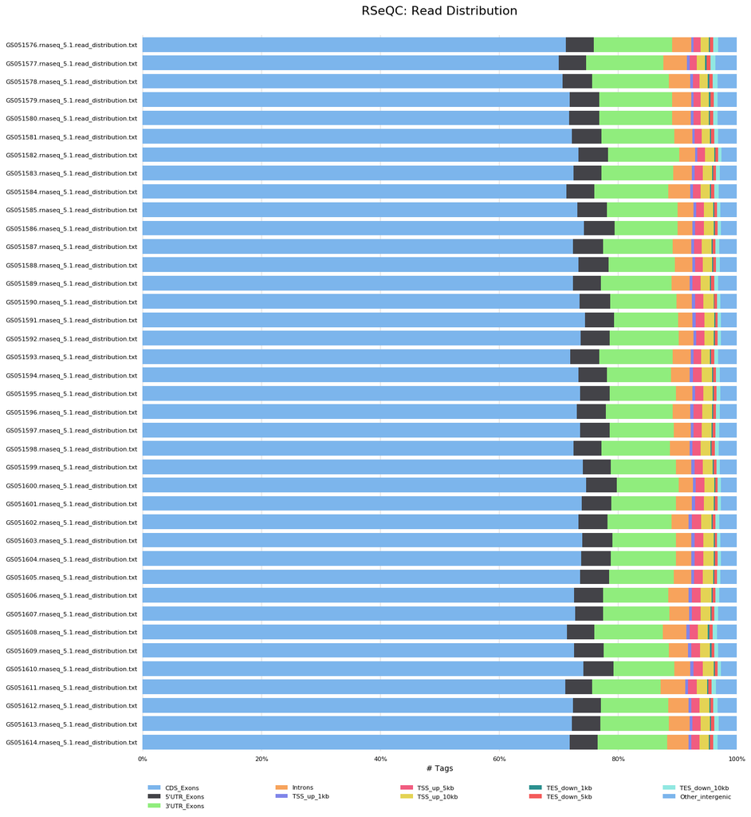